# pyMBE and molecular force fields

The Python-based Molecule Builder for ESPResSo (pyMBE) can interface with all-atom and CG force fields and automate the setup of force field parameters in ESPResSo.

This tutorial will focus on the AMBER99-SB and Martini 2.2 force fields.

Select mode:

- `"aa"` for all-atom model
- `"cg"` for coarse-grained model

```python
mode = "cg"
```

Install dependencies and patch ParmEd:

```
pip install vermouth insane ParmEd ipympl
sed -i "s/raise ParameterError('Not all angle parameters found/pass #raise ParameterError('Not all angle parameters found/" $(python3 -c "import parmed;print(parmed.__file__.rsplit('/', 1)[0] + '/gromacs/gromacstop.py')")
```

## Introduction

Import pyMBE library and other important libraries for this tutorial, such as ESPResSo and ParmEd.

```python
import os
import warnings
import pyMBE
import espressomd
import numpy as np
import matplotlib.pyplot as plt
import parmed.gromacs
parmed.gromacs.GROMACS_TOPDIR = os.path.join(os.environ["GMXDATA"], "top")
```

Download and prepare peptide:

```python
if not os.path.isfile("7ETN.pdb"):
    !wget https://files.rcsb.org/download/7ETN.pdb
if not os.path.isfile("martini_v2.2.itp"):
    !wget https://cgmartini-library.s3.ca-central-1.amazonaws.com/1_Downloads/ff_parameters/martini2/particle-definitions/martini_v2.2.itp
if not os.path.isfile("martini_v2.2_aminoacids.itp"):
    !wget https://cgmartini-library.s3.ca-central-1.amazonaws.com/1_Downloads/ff_parameters/martini2/aminoacids/martini_v2.2_aminoacids.itp
!rm -f topol.top
if mode == "aa":
    !rm -f peptide_aa.gro
if mode == "cg":
    !rm -f peptide_cg.gro
!sed "/ HOH A/d; /BARG A/d; /BLYS A/d; /BSER A/d; / B   /d;" 7ETN.pdb > peptide.pdb
if mode == "aa":
    !gmx pdb2gmx -f peptide.pdb -o peptide_aa.gro -ignh -ff amber99sb -water tip3p
if mode == "cg":
    !martinize2 -f peptide.pdb -x peptide_cg.pdb -o topol.top -ff martini22 -ss C -noscfix
    !gmx editconf -f peptide_cg.pdb -o peptide_cg.gro
    with open("martini.itp", "w") as f:
        f.write('#include "martini_v2.2.itp"\n#include "martini_v2.2_aminoacids.itp"\n')
```

[output not shown]

```python
def get_coord(atom):
    return [atom.xx, atom.xy, atom.xz]

def get_name(atom):
    if mode == "cg":
        return f"{atom.name}({atom.type})"
    if mode == "aa":
        return atom.name
```

```python
with warnings.catch_warnings(action="ignore"):
    gmx_top = parmed.gromacs.GromacsTopologyFile("topol.top")
    gmx_gro = parmed.gromacs.GromacsGroFile.parse(f"peptide_{mode}.gro")
gmx_top.positions = gmx_gro.positions
```

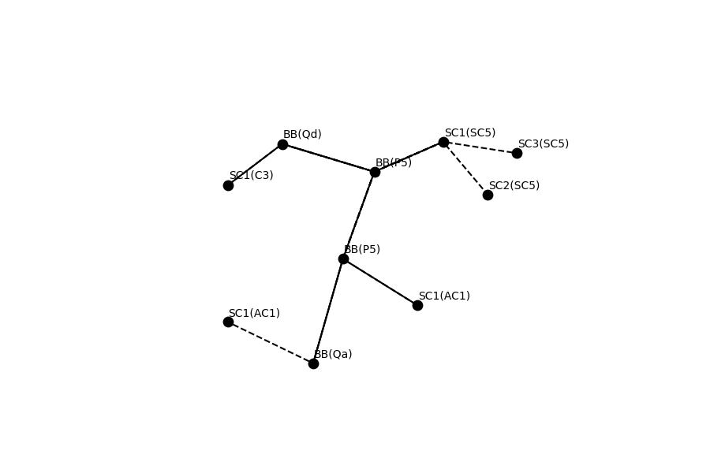

```python
from mpl_toolkits.mplot3d import Axes3D
%matplotlib widget
fig = plt.figure(figsize=(9, 6))
ax = fig.add_subplot(111, projection="3d")
for bond in gmx_top.bonds:
    ax.plot(*np.array([get_coord(bond.atom1), get_coord(bond.atom2)]).T, color="k")
for bond in gmx_top.angles:
    ax.plot(*np.array([get_coord(bond.atom1), get_coord(bond.atom2), get_coord(bond.atom3)]).T, color="k", ls="--")
for atom in gmx_top.atoms:
    ax.scatter(*get_coord(atom), marker="o", s=80, depthshade=False,
               edgecolors=None, c={1: "grey", 6: "green", 7: "blue", 8: "r"}.get(atom.atomic_number, "k"))
for atom in gmx_top.atoms:
    ax.text(*(get_coord(atom) + np.ones(3) * 0.15), get_name(atom))
ax.set_aspect("equal")
ax.set_xlabel("X axis")
ax.set_ylabel("Y axis")
ax.set_zlabel("Z axis")
ax.set_axis_off()
if mode == "aa":
    ax.view_init(elev=-10, azim=165, roll=-155, vertical_axis='z')
if mode == "cg":
    ax.view_init(elev=-12, azim=21, roll=16, vertical_axis='z')
plt.tight_layout()
```

Let us now create an instance of the ESPResSo system where we will place our molecules (a square simulation box with length = `box_l`).

```python
pmb = pyMBE.pymbe_library(seed=42)
```

When pyMBE is inicialized, a default system of reduced units is defined.

- Unit_length = 0.355 nm.
- Unit_charge = 1 elementary charge.
- Temperature = 298.15 K.

The active set of reduced units can be consulted using:

```python
print(pmb.get_reduced_units())
```

```
Current set of reduced units:
0.355 nanometer = 1 reduced_length
4.1164e-21 joule = 1 reduced_energy
1.6022e-19 coulomb = 1 reduced_charge
Temperature: 298.15 kelvin
```

```python
Box_L = 7.5*pmb.units.nm

espresso_system = espressomd.System(box_l = [Box_L.to('reduced_length').magnitude]*3)

print('The side of the simulation box is ', Box_L, '=' ,Box_L.to('reduced_length'))
```

```
The side of the simulation box is  7.5 nanometer = 21.126760563380284 reduced_length
```

## How to create simple polymers

pyMBE can be used to easily construct coarse-grained models of simple polymers. Let us consider a coarse grained model for polydehydroalanaline (PDha) (figure below) in which its monomeric unit can be represented by three beads, as depicted in the schematics below: a backbone bead (grey), a bead for the carboxylic acid group (red) and a bead for the amino group (blue).

[figure not shown]

To set up such polymer with pyMBE first one has to define the different particles in the monomer (or residue). Then, one defines the structure of the residue of the polymer. A residue is composed by a `central_bead` where one or various `side_chains` are attached. Each side chain can contain one particle or other residues.

NOTE: All input variables will be given to ESPResSo using these reduced units, since it is a convenient choice for the simulation setup. Internally, pyMBE uses Pint library to deal with unit transformations, which in turn should be used by the user to define its own variables.

```python
known_residues = set()
known_atoms = set()
for res in gmx_top.residues:
    if res.name in known_residues:
        continue
    known_residues.add(res.name)
    if mode == "cg":
        central_bead_cg = [get_name(atom) for atom in res.atoms if atom.name == "BB"][0]
    central_bead = "CA" if mode == "aa" else central_bead_cg
    pmb.define_residue(
        name=res.name,
        central_bead=central_bead,
        side_chains=[get_name(atom) for atom in res.atoms if atom.name not in ["CA", "BB"]])
    for atom in res.atoms:
        if get_name(atom) in known_atoms:
            continue
        known_atoms.add(get_name(atom))
        pmb.define_particle(name=get_name(atom),
                            z=atom.charge if mode == "cg" else int(1000*atom.charge),
                            sigma=(atom.sigma if mode == "aa" else 1.) * pmb.units('reduced_length'),
                            epsilon=(atom.epsilon if mode == "aa" else 1.) * pmb.units('reduced_energy'))
```

```python
pmb.filter_df(pmb_type='residue')
```

|  | name | pmb_type | central_bead | side_chains |
| --- | --- | --- | --- | --- |
| 0 | PRO | residue | BB(Qd) | [SC1(C3)] |
| 3 | PHE | residue | BB(P5) | [SC1(SC5), SC2(SC5), SC3(SC5)] |
| 8 | LEU | residue | BB(P5) | [SC1(AC1)] |
| 10 | ILE | residue | BB(Qa) | [SC1(AC1)] |

```python
pmb.filter_df(pmb_type='particle')
```

|  | name | pmb_type | sigma | cutoff | offset | epsilon | state_one label | state_one es_type | state_one z |
| --- | --- | --- | --- | --- | --- | --- | --- | --- | --- |
| 1 | BB(Qd) | particle | 1.0 reduced_length | 1.122462048309373 reduced_length | 0 reduced_length | 1.0 reduced_energy | BB(Qd) | 0 | 1 |
| 2 | SC1(C3) | particle | 1.0 reduced_length | 1.122462048309373 reduced_length | 0 reduced_length | 1.0 reduced_energy | SC1(C3) | 1 | 0 |
| 4 | BB(P5) | particle | 1.0 reduced_length | 1.122462048309373 reduced_length | 0 reduced_length | 1.0 reduced_energy | BB(P5) | 2 | 0 |
| 5 | SC1(SC5) | particle | 1.0 reduced_length | 1.122462048309373 reduced_length | 0 reduced_length | 1.0 reduced_energy | SC1(SC5) | 3 | 0 |
| 6 | SC2(SC5) | particle | 1.0 reduced_length | 1.122462048309373 reduced_length | 0 reduced_length | 1.0 reduced_energy | SC2(SC5) | 4 | 0 |
| 7 | SC3(SC5) | particle | 1.0 reduced_length | 1.122462048309373 reduced_length | 0 reduced_length | 1.0 reduced_energy | SC3(SC5) | 5 | 0 |
| 9 | SC1(AC1) | particle | 1.0 reduced_length | 1.122462048309373 reduced_length | 0 reduced_length | 1.0 reduced_energy | SC1(AC1) | 6 | 0 |
| 11 | BB(Qa) | particle | 1.0 reduced_length | 1.122462048309373 reduced_length | 0 reduced_length | 1.0 reduced_energy | BB(Qa) | 7 | -1 |

```python
summary = set()
for bond in gmx_top.bonds:
    identifier = f"{get_name(bond.atom1)}, {get_name(bond.atom2)}, {bond.type.k}, {bond.type.req}"
    if identifier in summary:
        continue
    summary.add(identifier)
    pmb.define_bond(bond_type="harmonic",
                    bond_parameters={"k": bond.type.k * pmb.units('reduced_energy / reduced_length**2'),
                                     "r_0": bond.type.req * pmb.units('reduced_length')},
                    particle_pairs = [[get_name(bond.atom1), get_name(bond.atom2)]])

summary = set()
for bond in gmx_top.angles:
    if bond.type is None:
        summary.add(f"need to add bond angle {get_name(bond.atom1)}-{get_name(bond.atom2)}-{get_name(bond.atom3)} theta_0=? k=?")
    else:
        summary.add(f"need to add bond angle {get_name(bond.atom1)}-{get_name(bond.atom2)}-{get_name(bond.atom3)} theta_0={bond.type.theteq:.2f} k={bond.type.k:.2f}")
for x in set(summary):
    print(x)

pmb.add_bonds_to_espresso(espresso_system=espresso_system)
```

```
need to add bond angle BB(Qd)-BB(P5)-BB(P5) theta_0=? k=?
need to add bond angle SC1(C3)-BB(Qd)-BB(P5) theta_0=? k=?
need to add bond angle BB(P5)-SC1(SC5)-SC2(SC5) theta_0=? k=?
need to add bond angle BB(P5)-SC1(SC5)-SC3(SC5) theta_0=? k=?
need to add bond angle BB(P5)-BB(P5)-SC1(AC1) theta_0=? k=?
need to add bond angle BB(P5)-BB(P5)-BB(Qa) theta_0=? k=?
need to add bond angle BB(P5)-BB(Qa)-SC1(AC1) theta_0=? k=?
need to add bond angle BB(Qd)-BB(P5)-SC1(SC5) theta_0=? k=?
```

```python
pmb.filter_df(pmb_type='bond')
```

|  | name | pmb_type | bond_object | parameters_of_the_potential | l0 |
| --- | --- | --- | --- | --- | --- |
| 12 | BB(Qd)-BB(P5) | bond | HarmonicBond({'r_cut': 0.0, 'k': 1.49378585086... | {'k': 1.4937858508604207, 'r_cut': 0.0, 'r_0':... | 3.5 |
| 13 | BB(P5)-BB(P5) | bond | HarmonicBond({'r_cut': 0.0, 'k': 1.49378585086... | {'k': 1.4937858508604207, 'r_cut': 0.0, 'r_0':... | 3.5 |
| 14 | BB(P5)-BB(Qa) | bond | HarmonicBond({'r_cut': 0.0, 'k': 1.49378585086... | {'k': 1.4937858508604207, 'r_cut': 0.0, 'r_0':... | 3.5 |
| 15 | BB(Qd)-SC1(C3) | bond | HarmonicBond({'r_cut': 0.0, 'k': 8.96271510516... | {'k': 8.962715105162523, 'r_cut': 0.0, 'r_0': ... | 3.0 |
| 16 | BB(P5)-SC1(SC5) | bond | HarmonicBond({'r_cut': 0.0, 'k': 8.96271510516... | {'k': 8.962715105162523, 'r_cut': 0.0, 'r_0': ... | 3.1 |
| 17 | BB(P5)-SC1(AC1) | bond | HarmonicBond({'r_cut': 0.0, 'k': 8.96271510516... | {'k': 8.962715105162523, 'r_cut': 0.0, 'r_0': ... | 3.3 |

NOTE: Currently, only harmonic and FENE bonds are supported.